[figure not shown]

# 1 The APSIM Peanut Model

The model has been developed using the Plant Modelling Framework (PMF) of Brown et al., 2014. This new framework provides a library of plant organ and process submodels that can be coupled, at runtime, to construct a model in much the same way that models can be coupled to construct a simulation.This means that dynamic composition of lower level process and organ classes(e.g.photosynthesis, leaf) into larger constructions(e.g.maize, wheat, sorghum) can be achieved by the model developer without additional coding.

The model consists of:

- a phenology model to simulate development between growth phases
- a structure model to simulate plant morphology
- a collection of organs to simulate the various plant parts
- an arbitrator to allocate resources (N, biomass) to the various plant organs

The model is constructed from the following list of software components. Details of the implementation and model parameterisation are provided in the following sections.

## 1.1 Plant Model Components

| Component Name | Component Type |
| --- | --- |
| Arbitrator | Models.PMF.OrganArbitrator |
| Phenology | Models.PMF.Phen.Phenology |
| Leaf | Models.PMF.Organs.SimpleLeaf |
| Grain | Models.PMF.Organs.ReproductiveOrgan |
| Root | Models.PMF.Organs.Root |
| Nodule | Models.PMF.Organs.Nodule |
| Shell | Models.PMF.Organs.GenericOrgan |
| Stem | Models.PMF.Organs.GenericOrgan |
| AflotoxinRisk | Models.Functions.BoundFunction |
| MortalityRate | Models.Functions.Constant |
| SeedMortalityRate | Models.Functions.Constant |

## 1.2 Composite Biomass

| Component Name | Component Type |
| --- | --- |
| AboveGround | Models.PMF.CompositeBiomass |
| BelowGround | Models.PMF.CompositeBiomass |
| AboveGroundLive | Models.PMF.CompositeBiomass |
| Total | Models.PMF.CompositeBiomass |
| TotalLive | Models.PMF.CompositeBiomass |
| TotalDead | Models.PMF.CompositeBiomass |
| Pod | Models.PMF.CompositeBiomass |

## 1.3 Cultivars

| Cultivar Name | Alternative Name(s) |
| --- | --- |
| EarlyBunch | EarlyBunch |
| VirginiaBunch | VirginiaBunch |
| TMV2 | TMV2 |
| Tapir | Tapir |
| VB97 | VB97 |
| Florunner | Florunner |
| Redvale | Redvale |
| Taabinga | Taabinga |
| Holt | Holt |

## 1.4 Child Components

### 1.4.1 Arbitrator

The Arbitrator class determines the allocation of dry matter (DM) and Nitrogen between each of the organs in the crop model. Each organ can have up to three different pools of biomass:

- **Structural biomass** which is essential for growth and remains within the organ once it is allocated there.
- **Metabolic biomass** which generally remains within an organ but is able to be re allocated when the organ senesces and may be retranslocated when demand is high relative to supply.
- **Storage biomass** which is partitioned to organs when supply is high relative to demand and is available for retranslocation to other organs whenever supply from uptake, fixation, or re allocation is lower than demand.

The process followed for biomass arbitration is shown in the figure below. Arbitration calculations are triggered by a series of events (shown below) that are raised every day. For these calculations, at each step the Arbitrator exchange information with each organ, so the basic computations of demand and supply are done at the organ level, using their specific parameters.

1. **doPotentialPlantGrowth**. When this event occurs, each organ class executes code to determine their potential growth, biomass supplies and demands. In addition to demands for structural, non structural and metabolic biomass (DM and N) each organ may have the following biomass supplies:
- **Fixation supply**. From photosynthesis (DM) or symbiotic fixation (N)
- **Uptake supply**. Typically uptake of N from the soil by the roots but could also be uptake by other organs (eg foliage application of N).
- **Retranslocation supply**. Storage biomass that may be moved from organs to meet demands of other organs.
- **Reallocation supply**. Biomass that can be moved from senescing organs to meet the demands of other organs.
2. **doPotentialPlantPartitioning.** On this event the Arbitrator first executes the DoDMSetup() method to gather the DM supplies and demands from each organ, these values are computed at the organ level. It then executes the DoPotentialDMAllocation() method which works out how much biomass each organ would be allocated assuming N supply is not limiting and sends these allocations to the organs. Each organ then uses their potential DM allocation to determine their N demand (how much N is needed to produce that much DM) and the arbitrator calls DoNSetup() to gather the N supplies and demands from each organ and begin N arbitration. Firstly DoNReallocation() is called to redistribute N that the plant has available from senescing organs. After this step any unmet N demand is considered as plant demand for N uptake from the soil (N Uptake Demand).
3. **doNutrientArbitration.** When this event occurs, the soil arbitrator gets the N uptake demands from each plant (where multiple plants are growing in competition) and their potential uptake from the soil and determines how much of their demand that the soil is able to provide. This value is then passed back to each plant instance as their Nuptake and doNUptakeAllocation() is called to distribute this N between organs.
4. **doActualPlantPartitioning.** On this event the arbitrator call DoNRetranslocation() and DoNFixation() to satisfy any unmet N demands from these sources. Finally, DoActualDMAllocation is called where DM allocations to each organ are reduced if the N allocation is insufficient to achieve the organs minimum N concentration and final allocations are sent to organs.

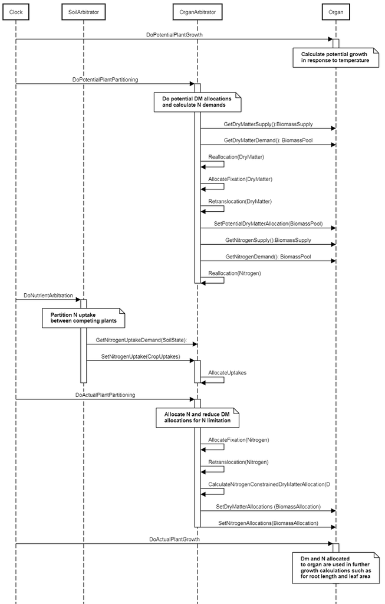

### 1.4.2 Phenology

The phenological development is simulated as the progression through a series of developmental phases, each bound by distinct growth stage.

In the new model we simplified phenology by taking out stages that are not measurable (e.g. end of juvenile stage) and by adding new stages that are measurable (e.g. start pod). The new phenology follows the V/R staging system

### 1.4.3 Leaf

This organ is simulated using a SimpleLeaf organ type. It provides the core functions of intercepting radiation, producing biomass through photosynthesis, and determining the plant's transpiration demand. The model also calculates the growth, senescence, and detachment of leaves. SimpleLeaf does not distinguish leaf cohorts by age or position in the canopy.

Radiation interception and transpiration demand are computed by the MicroClimate model. This model takes into account competition between different plants when more than one is present in the simulation. The values of canopy Cover, LAI, and plant Height (as defined below) are passed daily by SimpleLeaf to the MicroClimate model. MicroClimate uses an implementation of the Beer Lambert equation to compute light interception and the Penman Monteith equation to calculate potential evapotranspiration. These values are then given back to SimpleLeaf which uses them to calculate photosynthesis and soil water demand.

SimpleLeaf has two options to define the canopy: the user can either supply a function describing LAI or a function describing canopy cover directly. From either of these functions SimpleLeaf can obtain the other property using the Beer Lambert equation with the specified value of extinction coefficient. The effect of growth rate on transpiration is captured by the Fractional Growth Rate (FRGR) function, which is passed to the MicroClimate model.

### 1.4.4 Grain

This organ uses a generic model for plant reproductive components. Yield is calculated from its components in terms of organ number and size (for example, grain number and grain size).

### 1.4.5 Root

The root model calculates root growth in terms of rooting depth, biomass accumulation and subsequent root length density in each soil layer.

### 1.4.6 Nodule

This organ simulates the root structure associate with symbiotic N fixing bacteria. It provides the core functions of determining N fixation supply and related costs. It also calculates the growth, senescence and detachment of nodules.

### 1.4.7 Shell

This organ is simulated using a GenericOrgan type. It is parameterised to calculate the growth, senescence, and detachment of any organ that does not have specific functions.

### 1.4.8 Stem

This organ is simulated using a GenericOrgan type. It is parameterised to calculate the growth, senescence, and detachment of any organ that does not have specific functions.

### 1.4.9 AflotoxinRisk

Bounds the child function between lower and upper bounds

### 1.4.10 MortalityRate

A constant function (name=value)

### 1.4.11 SeedMortalityRate

A constant function (name=value)

# 2 Validation

## 2.3 Australia

| Experiment Name | Design (Number of Treatments) |
| --- | --- |
| Kingaroy8384 | Sow x Cv (33) |
| Kingaroy8485 | Sow x Pop (6) |
| Kingaroy8990 | Cv (3) |
| Kingaroy1819 | Cv x Irrigation (4) |
| Kunnunura8182 | Pop (2) |
| Kunnunura8283 | Sow (5) |
| Bundaberg8990 | Cv (4) |
| Loxton9697 | Pop (6) |
| Roseworthy96 | Sow x Cv (9) |

This dataset (Bell, 1992) provides data on growth for three cultivars grown under irrigated conditions in at Kingaroy in Queensland. The soil type was a deep, red clay-loam with a friable structure and increasing clay content with depth. Supplementary irrigations were made to avoid moisture stress.

This dataset (Bell, 1986) includes the cultvar "EarlyBunch" grown on 5 sowing dates under irrigated conditions in a monsoonal tropical environment at Kunnunura in Northern Australia. Plants were sampled regularly for biomass partitioning and canopy development. The soil is known locally as a normal phase Cockatoo Sand - an acid, coarse-textured and well-drained soil. Supplementary irrigations were made to avoid moisture stress.

This dataset (Bell, 1994) studied N fixation of various Peanut cultivars at Bundaberg, Queensland, Australia. The soil type was a deep, red clay-loam with a friable structure and increasing clay content with depth. The experiment was grown under irrigated conditions. Measurements were undertaken for biomass and nitrogen contents, and estimates of the contribution of N fixation to plant N contents.

This dataset (Porter, 2000) studied the impact of plant population on growth and productivity. Here we consider the cultvar EarlyBunch only (the comparison cultivar failed during the trial). The experiment was grown under irrigated conditions in at Loxton in South Australia. The soil type was sandy loam with good drainage but low water holding capacity. Supplementary irrigations were made to avoid moisture stress.

This dataset (Porter, 2000) studied the impact of sowing date on flowering and maturity for 24 germplasm lines. Here we consider the cultvars EarlyBunch, Florunner, and VB97. The experiment was grown under irrigated conditions in at Roseworthy in South Australia. The soil type was clay-loam with good water holding capacity. well-drained soil. Supplementary irrigations were made to avoid moisture stress.

## 2.4 USA

### 2.4.1 Headland Florunner

This dataset (Davis, 1991) studied the differences in canopy development for florunner cultivars. The experiment was grown under irrigated conditions at the Wiregrass Substation in Headland, Alabama. Supplementary irrigations were made to avoid moisture stress. Plants were sampled for plant vegetative stage, reproductive stage, height, number of leaves, leaf area, leaf dry weight, number of pods, pod dry weight, stem dry weight, and stand density.

| Experiment Name | Design (Number of Treatments) |
| --- | --- |
| Headland88 | Cv (1) |

### 2.4.2 Gainsville EarlyBunch

This dataset (from Hammer_etal_QNut) studied the differences in growth for two cultivars. We include only the cultivar "EarlyBunch". The experiment was grown under irrigated conditions at Gainesville, Florida. Supplementary irrigations were made to avoid moisture stress. Plants were sampled for total biomass, pod biomass and leaf area index.

| Experiment Name | Design (Number of Treatments) |
| --- | --- |
| Gainsville90 | Cv (1) |

# 3 Sensibility

## 3.1 DetailedDynamics

| Experiment Name | Design (Number of Treatments) |
| --- | --- |
| DetailedDynamics | Sow (1) |

## 3.2 Aflotoxin Risk

| Experiment Name | Design (Number of Treatments) |
| --- | --- |
| Aflotoxin | Cv x Sow (4) |

## 3.3 NewZealand

| Experiment Name | Design (Number of Treatments) |
| --- | --- |
| NewZealand | Water (2) |

Peanuts are currently being evaluated as a crop for the Northlands region of northern New Zealand. Test crops in the region are currently yielding up to 6-7 t/ha (Fresh Weight), which would correspond to a dry pod weight of 5-6 t/ha (16%-20% moisture).

# 4 UnderDevelopment

| Experiment Name | Design (Number of Treatments) |
| --- | --- |
| Roseworthy9798 | Pop x SR (16) |

This dataset (Porter, 2000) studied the impact of spatial arrangement on peanut crop microenvironment for the cultvar VB97. The experiment was grown under irrigated conditions in at Roseworthy in South Australia. The soil type was clay-loam with good water holding capacity. well-drained soil. Supplementary irrigations were made to avoid moisture stress. Treatments included a full factorial of population (8.8, 27.3, 39.4 and 58.8 plants/m^2) and Spatial Ratio (1:1, 1:2.2, 1:4.6 and 1:7.2 Inter-row:Intra-row).

# References

Bell, M., 1986. Effect of sowing date on growth and development of irrigated peanuts, Arachis hypogaea L. cv. Early Bunch, in a monsoonal tropical environment.. Australian Journal of Agricultural Research 37, 361-373.

Bell, MJ, Wright, GC, 1994. The N2-fixing capacity of peanut cultivars with differing assimilate partitioning characteristics. Australian Journal of Agricultural Research 45, 1455-1468.

Bell, MJ, Wright, GC, Hammer, GL, 1992. Night Temperature Affects Radiation-Use Efficiency in Peanut. Crop Science 32, 1329-1335.

[Brown, Hamish E., Huth, Neil I., Holzworth, Dean P., Teixeira, Edmar I., Zyskowski, Rob F., Hargreaves, John N. G., Moot, Derrick J., 2014. Plant Modelling Framework: Software for building and running crop models on the APSIM platform. Environmental Modelling and Software 62, 385-398.](http://www.sciencedirect.com/science/article/pii/S1364815214002588)

Davis, David P., Mack, Timothy P., 1991. Relations Between Leaf Area Index and Growth Characteristics of Florunner, Southern Runner, and Sunrunner Peanut. Peanut Science 18, 30-37.

Porter, Wade, 2000. Potential for peanut production in Southern Australia..